# 2. Регрессионный анализ

Authors

Машукова Анастасия (1 и 2 задания)

Павловская Арина (3 задание)

Чернорыж Яна

```r
data <- read_excel("data/HW_data.xlsx")

data <- data |>
  mutate(
    InfSeverity = factor(
      InfSeverity,
      levels = c(1, 2, 3),
      labels = c("Лёгкая", "Среднетяжёлая", "Тяжёлая"),
    ),
    Smoke = as.factor(Smoke)
  )
```

## 1.Нас интересует, ассоциирована ли функция легких (измеряемая как ОФВ1) с тяжестью индексной инфекции, перенесенной ребенком.

```r
df <- data
```

Гипотеза:  
$H_0: \mu_1 = \mu_2 = \mu_3$ Средние z-оценки ОФВ1 в каждой группе по тяжести индексной инфекции равны

$H_1: \exists\, i,j:\ \mu_i \neq \mu_j$ Хотя бы одно из пар равенств нарушено

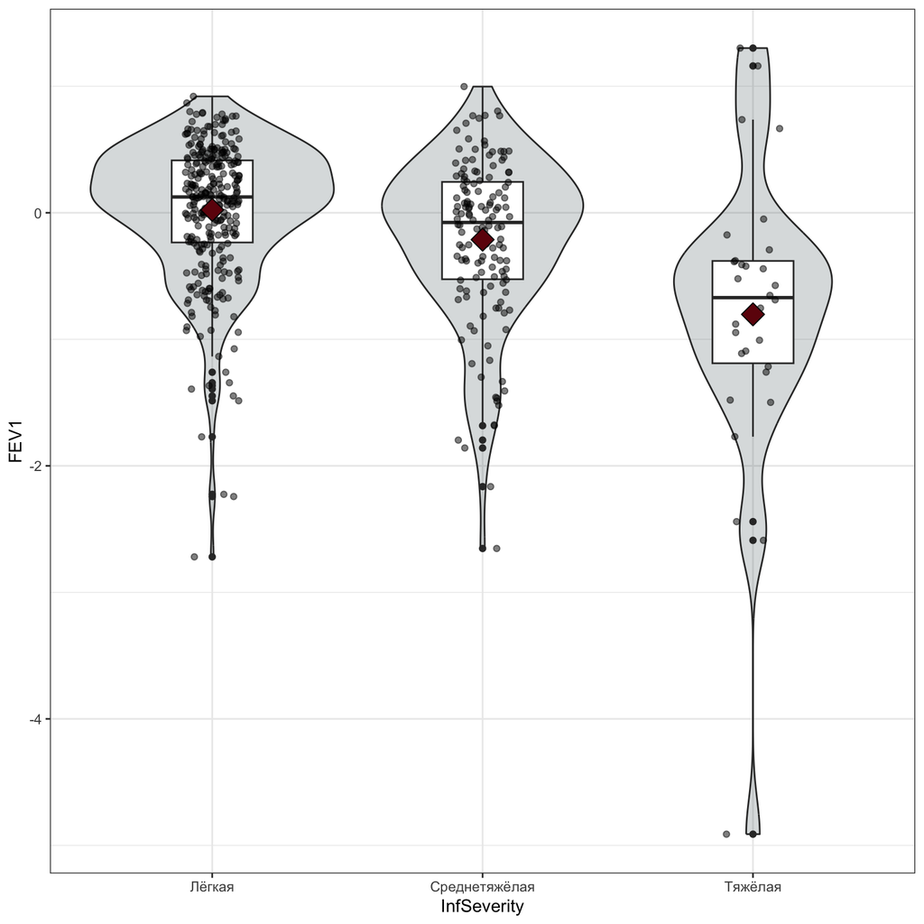

```r
set.seed(42)

df |>
    ggplot(aes(x = InfSeverity, y = FEV1)) +
    geom_violin(fill = "#374E55", alpha = 0.2) +
    geom_boxplot(width = 0.3) +
    geom_jitter(alpha = 0.5, width = 0.1) +
    stat_summary(
        fun = mean,
        geom = "point",
        shape = 23,
        size = 5,
        color = "black",
        fill = "#6e0c0c"
    ) +
    theme_bw()
```

Интерпретация: постепенное снижение медианы и среднего значения z-оценки с ростом тяжести инфекции. В 3 группе больше аутлайеров и они более экстремальные. С ростом тяжести меняется форма распределения: от почти симметричной (1 и 2 группы) к асимметричной со скосом влево и тяжелым левым хвостом (3 группа)

Модель: Классический anova Фишера

```r
aov(FEV1 ~ InfSeverity, data = df) |> summary()
```

```
             Df Sum Sq Mean Sq F value  Pr(>F)
InfSeverity   2  21.09  10.546   25.94 2.1e-11 ***
Residuals   464 188.64   0.407
---
Signif. codes:  0 '***' 0.001 '**' 0.01 '*' 0.05 '.' 0.1 ' ' 1
```

Интерпретация : Отвергаем $H_0$ (p-value = 2.1e-11), среднее хотя бы одной из групп статистически значимо различается от другой

```r
m1 <- lm(FEV1 ~ InfSeverity, data = df)
m1 |> summary()
```

```
Call:
lm(formula = FEV1 ~ InfSeverity, data = df)

Residuals:
    Min      1Q  Median      3Q     Max
-4.1084 -0.2889  0.1097  0.4139  2.1045

Coefficients:
                         Estimate Std. Error t value Pr(>|t|)
(Intercept)               0.02322    0.03712   0.626 0.531883
InfSeverityСреднетяжёлая -0.23564    0.06513  -3.618 0.000329 ***
InfSeverityТяжёлая       -0.82604    0.12219  -6.760 4.15e-11 ***
---
Signif. codes:  0 '***' 0.001 '**' 0.01 '*' 0.05 '.' 0.1 ' ' 1

Residual standard error: 0.6376 on 464 degrees of freedom
Multiple R-squared:  0.1006,    Adjusted R-squared:  0.09668
F-statistic: 25.94 on 2 and 464 DF,  p-value: 2.096e-11
```

Уравнение регрессии:
$$E[FEV1|InfSeverity = degree] = \beta_0 + \beta_1 \mathbb{I}[InfSeverity = 2] + \beta_2 \mathbb{I}[InfSeverity = 3]$$
Интерпретация линейной модели:
(Intercept) - среднее значение z-оценки при 1 степени тяжести (референс)
InfSeverity2 - разница в среднем значении z-оценки между 2 группой и 1 группой тяжести
InfSeverity3 - разница в среднем значении z-оценки между 3 группой и 1 группой тяжести

Субмодель:

```r
m1_sub <- lm(FEV1 ~ 1, data = df)
m1_sub |> summary()
```

```
Call:
lm(formula = FEV1 ~ 1, data = df)

Residuals:
    Min      1Q  Median      3Q     Max
-4.8098 -0.3346  0.1454  0.4690  1.4032

Coefficients:
            Estimate Std. Error t value Pr(>|t|)
(Intercept) -0.10149    0.03104  -3.269  0.00116 **
---
Signif. codes:  0 '***' 0.001 '**' 0.01 '*' 0.05 '.' 0.1 ' ' 1

Residual standard error: 0.6709 on 466 degrees of freedom
```

Интерпретация: Отвергаем $H_0$ о том, что средняя z-оценка по выборке = 0

Тест модель-субмодель:

```r
anova(m1, m1_sub)
```

```
Analysis of Variance Table

Model 1: FEV1 ~ InfSeverity
Model 2: FEV1 ~ 1
  Res.Df    RSS Df Sum of Sq      F    Pr(>F)
1    464 188.65
2    466 209.74 -2   -21.091 25.939 2.096e-11 ***
---
Signif. codes:  0 '***' 0.001 '**' 0.01 '*' 0.05 '.' 0.1 ' ' 1
```

Интерпретация: $H_0$ отвергаем (p=2.10e-11) о том, что более узкой модели (m1_sub) достаточно для описания наших данных

## 2. Правда ли, что у курящих родителей тяжесть индексной инфекции ассоциирована с функцией легких иным образом, чем у родителей некурящих?

Гипотеза:  
$H_0$: все коэффициенты взаимодействия = 0  
$H_1$: хотя бы один коэффициент взаимодействия $\neq$ 0

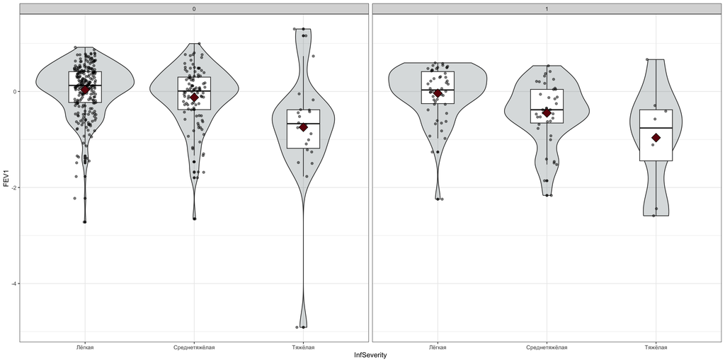

```r
df |>
    ggplot(aes(x = InfSeverity, y = FEV1)) +
    geom_violin(fill = "#374E55", alpha = 0.2) +
    geom_boxplot(width = 0.3) +
    geom_jitter(alpha = 0.5, width = 0.1) +
    stat_summary(
        fun = mean,
        geom = "point",
        shape = 23,
        size = 5,
        color = "black",
        fill = "#6e0c0c"
    ) +
    facet_wrap(~Smoke) +
    theme_bw()
```

```r
m2 <- lm(FEV1 ~ InfSeverity * Smoke, data = df)
m2 |> summary()
```

```
Call:
lm(formula = FEV1 ~ InfSeverity * Smoke, data = df)

Residuals:
    Min      1Q  Median      3Q     Max
-4.1665 -0.2631  0.0931  0.4040  2.0465

Coefficients:
                                Estimate Std. Error t value Pr(>|t|)
(Intercept)                      0.03552    0.04049   0.877   0.3809
InfSeverityСреднетяжёлая        -0.15893    0.07443  -2.135   0.0333 *
InfSeverityТяжёлая              -0.78028    0.14106  -5.532 5.33e-08 ***
Smoke1                          -0.07252    0.09835  -0.737   0.4613
InfSeverityСреднетяжёлая:Smoke1 -0.25156    0.15451  -1.628   0.1042
InfSeverityТяжёлая:Smoke1       -0.14514    0.27954  -0.519   0.6039
---
Signif. codes:  0 '***' 0.001 '**' 0.01 '*' 0.05 '.' 0.1 ' ' 1

Residual standard error: 0.6338 on 461 degrees of freedom
Multiple R-squared:  0.1171,    Adjusted R-squared:  0.1075
F-statistic: 12.23 on 5 and 461 DF,  p-value: 3.812e-11
```

Интерпретация:  
(Intercept) - средняя z-оценка детей с 1 степенью тяжести инфекции с некурящими родителями. $H_0$ о том, что константа регрессии = 0 не отвергается (p = 0.3809)  
InfSeverity2 - разница средних z-оценок между 2 и 1 степенями тяжести инфекции при условии некурящих родителей. $H_0$ о том, что коэффициент = 0 отвергается (p = 0.0333)  
InfSeverity3 - разница средних z-оценок между 3 и 1 степенями тяжести инфекции при условии некурящих родителей. $H_0$ о том, что коэффициент = 0 отвергается (p = 5.33e-08)  
Smoke - разница средних z-оценок между детьми с курящими родителями и некурящими при 1 степени тяжести инфекции. $H_0$ о том, что коэффициент = 0 не отвергается (p = 0.4613)  
InfSeverity2:Smoke - разница средних z-оценок между 2 и 1 степенями тяжести инфекции у детей с курящими родителями по сравнению с некурящими. $H_0$ о том, что коэффициент = 0 не отвергается (p = 0.1042)  
InfSeverity3:Smoke - разница средних z-оценок между 3 и 1 степенями тяжести инфекции у детей с курящими родителями по сравнению с некурящими. $H_0$ о том, что коэффициент = 0 не отвергается (p = 0.6039)

```r
m2_sub <- lm(FEV1 ~ InfSeverity + Smoke, data = df)
m2_sub |> summary()
```

```
Call:
lm(formula = FEV1 ~ InfSeverity + Smoke, data = df)

Residuals:
    Min      1Q  Median      3Q     Max
-4.1559 -0.2792  0.1024  0.4029  2.0571

Coefficients:
                         Estimate Std. Error t value Pr(>|t|)
(Intercept)               0.05336    0.03894   1.370 0.171251
InfSeverityСреднетяжёлая -0.21695    0.06523  -3.326 0.000952 ***
InfSeverityТяжёлая       -0.80876    0.12175  -6.643 8.66e-11 ***
Smoke1                   -0.17780    0.07291  -2.439 0.015113 *
---
Signif. codes:  0 '***' 0.001 '**' 0.01 '*' 0.05 '.' 0.1 ' ' 1

Residual standard error: 0.6342 on 463 degrees of freedom
Multiple R-squared:  0.112, Adjusted R-squared:  0.1062
F-statistic: 19.46 on 3 and 463 DF,  p-value: 6.736e-12
```

Интерпретация:  
(Intercept) - средняя z-оценка при 1 степени тяжести у детей с некурящими родителями. $H_0$ о том, что константа регрессии = 0 не отвергается (p = 0.171)  
InfSeverity2 - разница средних z-оценок между 1 и 2 степенями тяжести у детей при прочих равных условиях (одинаковый статус курения родителей). $H_0$ о том, что коэффициент = 0 отвергается (p = 0.0009)  
InfSeverity3 - разница средних z-оценок между 1 и 3 степенями тяжести у детей при прочих равных условиях. $H_0$ о том, что коэффициент = 0 отвергается (p = 8.66e-11)  
Smoke - разница средних z-оценок детей между курящими и некурящими родителями при одинаковой степени тяжести инфекции. $H_0$ о том, что коэффициент = 0 отвергается (p= 0.0151)

Тест модель-субмодель:

```r
anova(m2, m2_sub)
```

```
Analysis of Variance Table

Model 1: FEV1 ~ InfSeverity * Smoke
Model 2: FEV1 ~ InfSeverity + Smoke
  Res.Df    RSS Df Sum of Sq     F Pr(>F)
1    461 185.18
2    463 186.25 -2   -1.0749 1.338 0.2634
```

Интерпретация: Не отвергаем $H_0$ (p=0.263) о том, что аддитивной модели достаточно для описания/коэффициенты пересечения между эффектами InfSeverity и Smoke = 0

Таким образом, характер ассоциации тяжести инфекции с функцией легких у детей курящих и некурящих родителей статистически значимо не различается

## 3. Правда ли, что функция легких по-разному ассоциирована с индексным возрастом у пациентов с разной тяжестью индексной инфекции

#### Исследовательский вопрос

Различается ли ассоциация функции легких у детей в возрасте 8 лет с индексным возрастом заболевания пациентов в зависимости от тяжести индексной инфекции

#### Эксплораторный анализ

```r
data |>
  group_by(InfSeverity) |>
  summarise(
    n = sum(!is.na(FEV1) & !is.na(AgeIndex)),
    mean_FEV1 = mean(FEV1, na.rm = TRUE),
    sd_FEV1 = sd(FEV1, na.rm = TRUE),
    var_FEV1 = var(FEV1, na.rm = TRUE),
    mean_AgeIndex = mean(AgeIndex, na.rm = TRUE),
    sd_AgeIndex = sd(AgeIndex, na.rm = TRUE),
    var_AgeIndex = var(AgeIndex, na.rm = TRUE)
  ) |>
  flextable()
```

| InfSeverity | n | mean_FEV1 | sd_FEV1 | var_FEV1 | mean_AgeIndex | sd_AgeIndex | var_AgeIndex |
| --- | --- | --- | --- | --- | --- | --- | --- |
| Лёгкая | 295 | 0.02322472 | 0.5479120 | 0.3002076 | 15.55441 | 5.345564 | 28.57506 |
| Среднетяжёлая | 142 | -0.21241829 | 0.6531089 | 0.4265513 | 15.09327 | 5.519478 | 30.46464 |
| Тяжёлая | 30 | -0.80281162 | 1.1779559 | 1.3875802 | 14.03532 | 5.384804 | 28.99611 |

```r
data_clean <- data |> filter(row_number() != 308)
```

NB: Забегая вперед

- с наблюдением 308 взаимодействие было статистически значимым (p = 0.011)
- без него статистическая значимость не наблюдалась (p = 0.406)

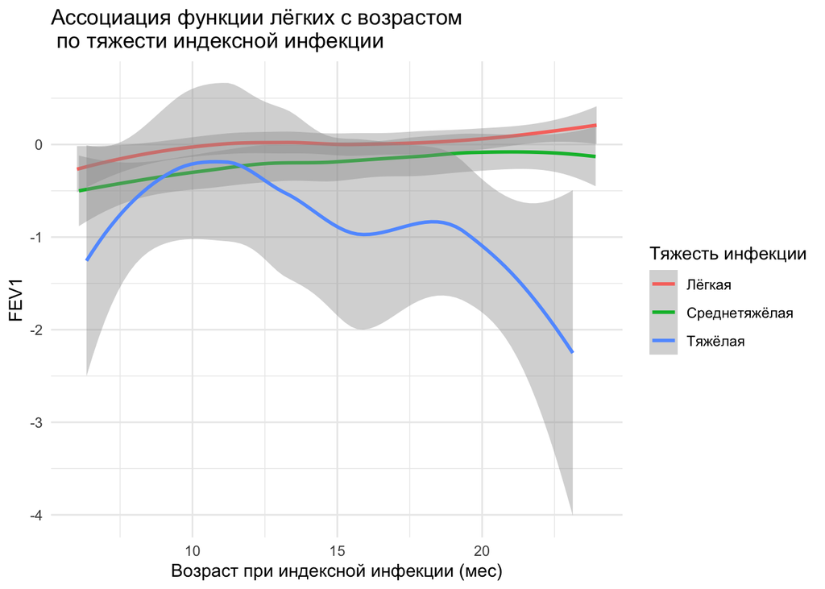

```r
ggplot(
  data,
  aes(
    x = AgeIndex,
    y = FEV1,
    color = InfSeverity
  )
) +
  geom_smooth(
    formula = y ~ x,
    se = TRUE
  ) +
  labs(
    title = "Ассоциация функции лёгких с возрастом \n по тяжести индексной инфекции",
    x = "Возраст при индексной инфекции (мес)",
    y = "FEV1",
    color = "Тяжесть инфекции"
  ) +
  theme_minimal()
```

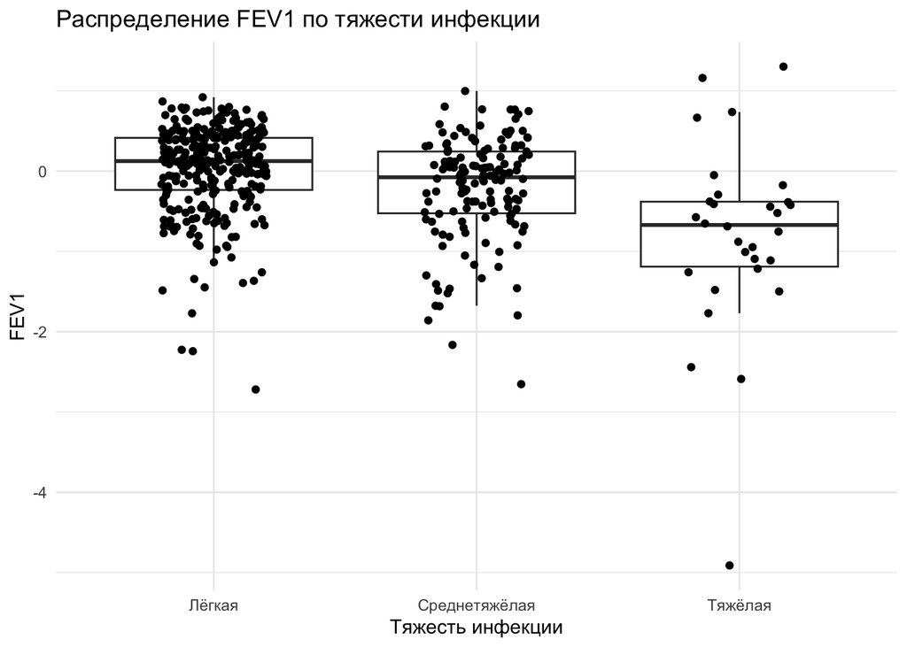

```r
ggplot(data) +
  aes(x = InfSeverity, y = FEV1) +
  geom_boxplot(
    outlier.shape = "",
  ) +
  geom_jitter(
    width = 0.2,
  ) +
  theme_minimal() +
  labs(
    x = "Тяжесть инфекции",
    y = "FEV1",
    title = "Распределение FEV1 по тяжести инфекции"
  )
```

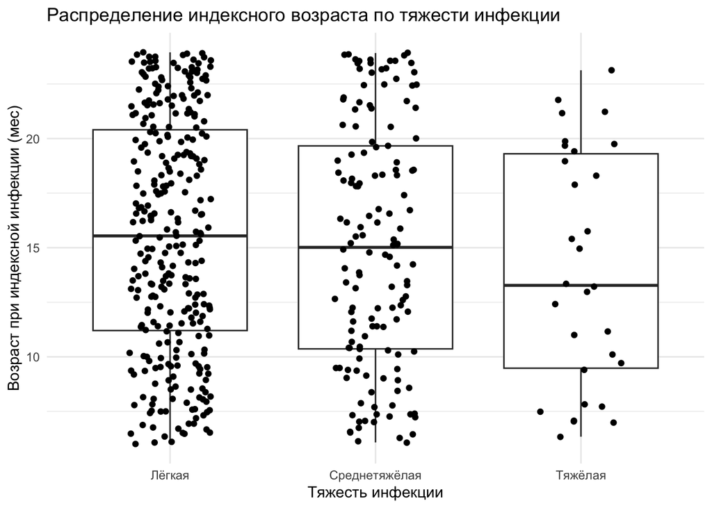

```r
ggplot(data) +
  aes(x = InfSeverity, y = AgeIndex) +
  geom_boxplot(outlier.shape = "") +
  geom_jitter(width = 0.2) +
  theme_minimal() +
  labs(
    x = "Тяжесть инфекции",
    y = "Возраст при индексной инфекции (мес)",
    title = "Распределение индексного возраста по тяжести инфекции"
  )
```

#### Гипотезы

H0 : ассоциация между функцией легких и индексным возрастом не зависит от тяжести индексной инфекции

H1: ассоциация между функцией легких и индексным возрастом зависит от тяжести индексной инфекции

#### Модели

1. $$FEV1_i = \beta_0 + \beta_1 AgeIndex_i + \beta_2 (InfSeverity_i == 2) + \beta_3 (InfSeverity_i == 3) + \varepsilon_i,$$
   где $FEV1_i$ – функция легких у i-го пациента $AgeIndex_i$ – возраст ребёнка в месяцах при индексном эпизоде $InfSeverity_i$ – тяжесть индексной инфекции – категориальный признак: 1 – лёгкое течение, 2 – среднетяжёлое течение, 3 – тяжёлая инфекция
2. Рассмотрим взаимодействие возраста и тяжести индексной инфекции: $AgeIndex \times InfSeverity$

$$FEV1_i = \beta_0 + \beta_1 AgeIndex_i + \beta_2 (InfSeverity_i == 2) + \beta_3 (InfSeverity_i == 3) + \beta_4 AgeIndex_i (InfSeverity_i == 2) + \beta_5 AgeIndex_i (InfSeverity_i == 3) + \varepsilon_i,$$

NB: $H0: \beta_4 = \beta_5 = 0$

#### Проверка гипотез

```r
model_no_assosiation <- lm(
  FEV1 ~ AgeIndex + InfSeverity,
  data = data
)

model_with_assosiation <- lm(
  FEV1 ~ AgeIndex * InfSeverity,
  data = data
)


anova(model_no_assosiation, model_with_assosiation) |> flextable()
```

| Res.Df | RSS | Df | Sum of Sq | F | Pr(>F) |
| --- | --- | --- | --- | --- | --- |
| 463 | 186.0086 |  |  |  |  |
| 461 | 182.4116 | 2 | 3.596986 | 4.545245 | 0.01109777 |

```r
model_no_assosiation_clean <- lm(
  FEV1 ~ AgeIndex + InfSeverity,
  data = data_clean
)

model_with_assosiation_clean <- lm(
  FEV1 ~ AgeIndex * InfSeverity,
  data = data_clean
)

anova(model_no_assosiation_clean, model_with_assosiation_clean) |> flextable()
```

| Res.Df | RSS | Df | Sum of Sq | F | Pr(>F) |
| --- | --- | --- | --- | --- | --- |
| 462 | 167.5315 |  |  |  |  |
| 460 | 166.8767 | 2 | 0.6548152 | 0.9025076 | 0.4062683 |

#### Интерпретация результатов

При включении всех наблюдений выявлено статистически значимое взаимодействие между индексным возрастом и тяжестью инфекции (F = 4.5452 p = 0.0111). Однако после исключения наблюдения 308 статистическая значимость взаимодействия отсутствовала (F = 0.9025 p = 0.406)

Результат анализа чувствителен к одному наблюдению. После его исключения статистически значимых свидетельств того, что ассоциация между FEV1 и индексным возрастом различается в зависимости от тяжести инфекции, не обнаружено